# Week 3 session 2: Causality 2

### Implementing the varying-intercepts model in R

### We can also have varying treatment effects

```r
mod3 <- lmer(PostTest ~ Treatment + PreTest + (1 + Treatment | Grade), data = Electric_company)
#summary(mod3)
```

### Implementing the varying-intercepts model in R

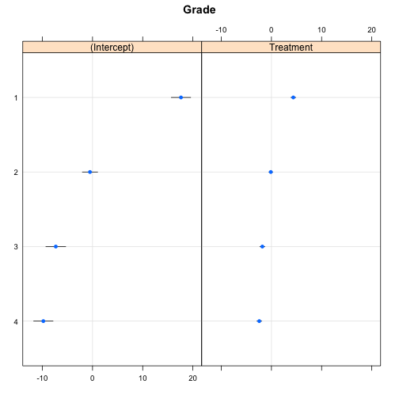

```r
library(lattice)
dotplot(ranef(mod3, condVar = T))
```

### Relationship to difference-in-differences

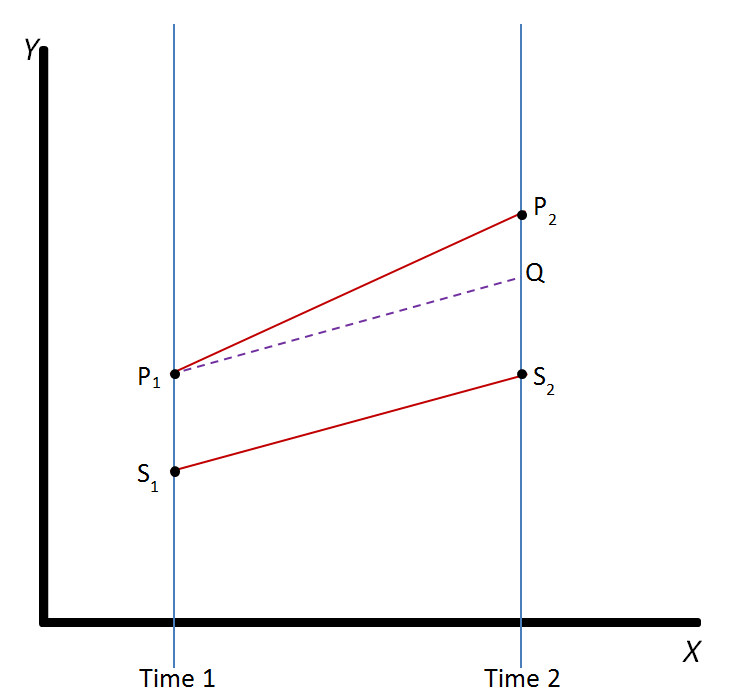

### Introducing propensity score matching

- Why does an experiment work?
  - The distribution of counfounders—both measured and unmeasured—is equal across treatment and control.

If we don't have a natural experiment or panel data, then perhaps it is least bad to build a **synthetic control group**. This will mean that our control group and treatment group are similar **on observed confounders**.

### Incomplete overlap

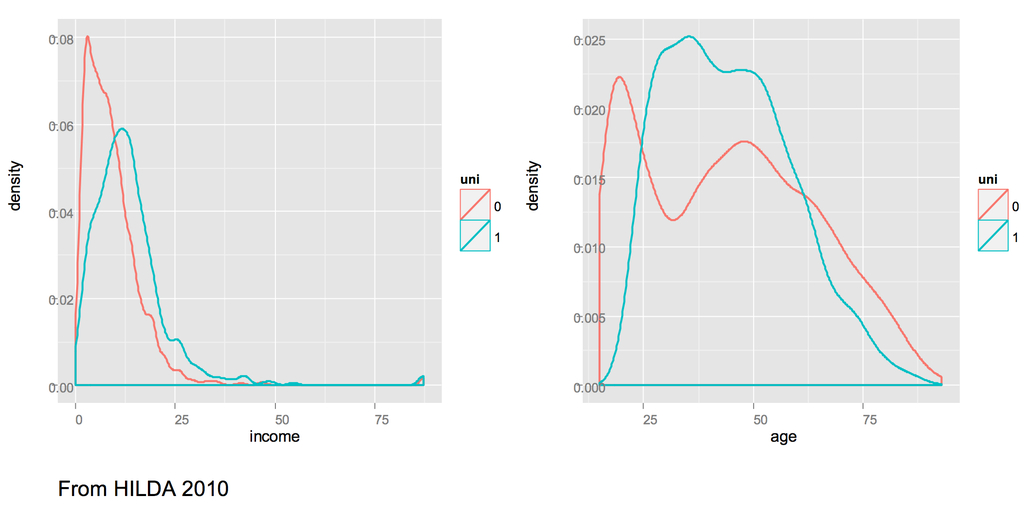

### So how do we create a matched control?

### “Exact matching” or “complete matching”

- Match each graduate man with a non-graduate man
  - Match each 25 year old graduate man with a 25 year old non-graduate man
    - Match each 25 year old graduate Asian man with a 25 year old non-graduate Asian man
      - …
- Upside is that you get great balance
- Downside is that you can't match on many confounders. You encounter a “dimensionality problem”

### So how do we create a matched control?

### Clustering

- Perform K-nearest-neighbours or some other clustering routine to group together similar people.
- Estimate “treatment effects” within each cluster
- Good thing is that you'll end up with a fairly balanced control group
- Bad thing is that you will balance on variables that may not matter